# IODS course project

# About the project

*At first **overwhelming** for non experienced programmers or advanced users in the computer field. Nonetheless, after a few hours of careful reading instructions and many self learning sessions in the provided tools one can start to understand that **sky is the limit** for the stubborn and motivated individuals.*

This course will allow you to master R language and give you insights in the possible ways you can use it to analyse different kinds of data.

- My Repository: https://github.com/ElsaMarques/IODS-project.git
- My learning diary: https://elsamarques.github.io/IODS-project/

# 1 Tools and methods for open and reproducible research

*This chapter allows you to learn how to use the course Softwares (*RStudio* & *GitHub desktop* & *GitHub*) and get the first contact with some of the basic RMarkdown codes*

## 1.1 **Work done during the week and learning summary.**

- Completed the following courses on DataCamp:
  - *“R short and sweet”* ;
  - *“Introduction to R”* (Extra ; highly recommend the daily exercises after finishing up this course, perfect and quick way to remind little things you learn till this moment);
  - *“DataCamp (EXTRA): Helsinki Social Statistics”* (Similar to the mandatory *“R short and Sweet”* but nothing like practicing to solidify the learn code, fucntions, etc.. )
  - *1st free chapters of “Intermediate R”" ; “Cleaning Data in R” & “Data manipulation in R With dplyr”* (Extra ; gave a clear idea on how complex this can become and once again good practice/reminder of basics learnt till now)
- Installed RStudio, GitHub desktop, and explored the RMarkdown Basics & R Code Chunks provided help lists.
  - Edited my profile picture and explored GitHub settings (Extra)
  - Succesfully forked the IODS project to personal repository & found my own repository and course diary link
  - Created the new file RMarkdown (README.Rmd)
  - Altered the team of the course diary in online GitHub (Extra)
  - Commited to my branch of the master repostiory my intermediate and final changes
  - Started working in the chapter2.Rmd by accident but sucessfully hide it from the 1st peer-review deadline
  - Managed to fix an error message in RStudio start up (Mac OS El Capitan version incompatibility)

# 2 Regression and model validation

*During this chapter the amount of information to be memorized is higher and more complex. The datacamp exercise, including the videos included in it touch the surface of what you can do to build graphs to visualize and analyse your data. Note that during this chapter you will definetily need to consult external help cheats (mostly provided during the datacamp and your mooc links)*

## 2.1 1. **Data wrangling exercise**

Load the data set provided (questionary answers regarding learning approaches and students accomplishments in a statistics course):

- All data provided in the url

```r
#read the data from URL provided link
lrn14 <- read.table("http://www.helsinki.fi/~kvehkala/JYTmooc/JYTOPKYS3-data.txt", sep="\t", header=TRUE)
```

Data after data wrangling exercises (stored locally)

```r
#read the data from file located in your hard drive
learning2014 <- read.csv("learning2014.csv")
```

- Questions related to the following topics were placed together:  
  - deep_questions , surface_questions , strategic_questions
2. **How to extract information from data**

Since the full data set can be overwelming to explore, viewing the structure, summary and the first values of the data can be helpful to identify what are your main interests in this questionary answers.

```r
#view the structure and summary of the non filtered "learning2014" data
str(lrn14)
```

```
## 'data.frame':    183 obs. of  60 variables:
##  $ Aa      : int  3 2 4 4 3 4 4 3 2 3 ...
##  $ Ab      : int  1 2 1 2 2 2 1 1 1 2 ...
##  $ Ac      : int  2 2 1 3 2 1 2 2 2 1 ...
##  $ Ad      : int  1 2 1 2 1 1 2 1 1 1 ...
##  $ Ae      : int  1 1 1 1 2 1 1 1 1 1 ...
##  $ Af      : int  1 1 1 1 1 1 1 1 1 2 ...
##  $ ST01    : int  4 4 3 3 4 4 5 4 4 4 ...
##  $ SU02    : int  2 2 1 3 2 3 2 2 1 2 ...
##  $ D03     : int  4 4 4 4 5 5 4 4 5 4 ...
##  $ ST04    : int  4 4 4 4 3 4 2 5 5 4 ...
##  $ SU05    : int  2 4 2 3 4 3 2 4 2 4 ...
##  $ D06     : int  4 2 3 4 4 5 3 3 4 4 ...
##  $ D07     : int  4 3 4 4 4 5 4 4 5 4 ...
##  $ SU08    : int  3 4 1 2 3 4 4 2 4 2 ...
```

[output cut: 46 more lines]

```r
summary(lrn14)
```

```
##        Aa             Ab              Ac              Ad
##  Min.   :1.00   Min.   :1.000   Min.   :1.000   Min.   :1.000
##  1st Qu.:2.00   1st Qu.:1.000   1st Qu.:1.000   1st Qu.:1.000
##  Median :3.00   Median :2.000   Median :2.000   Median :1.000
##  Mean   :3.06   Mean   :1.787   Mean   :2.077   Mean   :1.617
##  3rd Qu.:4.00   3rd Qu.:2.000   3rd Qu.:2.000   3rd Qu.:2.000
##  Max.   :5.00   Max.   :5.000   Max.   :5.000   Max.   :5.000
##        Ae              Af             ST01            SU02
##  Min.   :1.000   Min.   :1.000   Min.   :1.000   Min.   :1.000
##  1st Qu.:1.000   1st Qu.:1.000   1st Qu.:3.000   1st Qu.:2.000
##  Median :1.000   Median :1.000   Median :4.000   Median :2.000
##  Mean   :1.437   Mean   :1.579   Mean   :3.765   Mean   :2.612
##  3rd Qu.:1.000   3rd Qu.:2.000   3rd Qu.:4.000   3rd Qu.:4.000
##  Max.   :5.000   Max.   :5.000   Max.   :5.000   Max.   :5.000
##       D03             ST04            SU05            D06
##  Min.   :1.000   Min.   :1.000   Min.   :1.000   Min.   :1.000
##  1st Qu.:4.000   1st Qu.:2.000   1st Qu.:2.000   1st Qu.:3.000
##  Median :4.000   Median :3.000   Median :3.000   Median :4.000
##  Mean   :4.361   Mean   :3.213   Mean   :2.874   Mean   :3.448
##  3rd Qu.:5.000   3rd Qu.:4.000   3rd Qu.:4.000   3rd Qu.:4.000
##  Max.   :5.000   Max.   :5.000   Max.   :5.000   Max.   :5.000
##       D07            SU08            ST09            SU10
##  Min.   :1.00   Min.   :1.000   Min.   :1.000   Min.   :1.000
##  1st Qu.:4.00   1st Qu.:2.000   1st Qu.:2.000   1st Qu.:1.000
##  Median :4.00   Median :2.000   Median :4.000   Median :2.000
##  Mean   :3.94   Mean   :2.508   Mean   :3.224   Mean   :1.995
##  3rd Qu.:5.00   3rd Qu.:3.500   3rd Qu.:4.000   3rd Qu.:2.000
##  Max.   :5.00   Max.   :5.000   Max.   :5.000   Max.   :5.000
##       D11             ST12            SU13            D14
##  Min.   :2.000   Min.   :1.000   Min.   :1.000   Min.   :2.000
##  1st Qu.:4.000   1st Qu.:2.000   1st Qu.:2.000   1st Qu.:4.000
##  Median :4.000   Median :3.000   Median :2.000   Median :4.000
##  Mean   :3.934   Mean   :2.923   Mean   :2.546   Mean   :4.087
##  3rd Qu.:4.000   3rd Qu.:4.000   3rd Qu.:3.000   3rd Qu.:5.000
##  Max.   :5.000   Max.   :5.000   Max.   :5.000   Max.   :5.000
##       D15             SU16            ST17           SU18
##  Min.   :1.000   Min.   :1.000   Min.   :1.00   Min.   :1.000
##  1st Qu.:2.000   1st Qu.:2.000   1st Qu.:3.00   1st Qu.:1.000
##  Median :3.000   Median :3.000   Median :3.00   Median :1.000
##  Mean   :3.224   Mean   :2.814   Mean   :3.18   Mean   :1.902
```

[output cut: 50 more lines]

```
##  Max.   :5.00   Max.   :5.000   Max.   :5.000   Max.   :5.000
##        Dg              Dh              Di              Dj
##  Min.   :1.000   Min.   :1.000   Min.   :1.000   Min.   :1.000
##  1st Qu.:2.000   1st Qu.:2.000   1st Qu.:2.000   1st Qu.:3.000
##  Median :3.000   Median :3.000   Median :2.000   Median :4.000
##  Mean   :2.929   Mean   :2.913   Mean   :2.639   Mean   :3.951
##  3rd Qu.:4.000   3rd Qu.:4.000   3rd Qu.:4.000   3rd Qu.:5.000
##  Max.   :5.000   Max.   :5.000   Max.   :5.000   Max.   :5.000
##       Age           Attitude         Points      gender
##  Min.   :17.00   Min.   :14.00   Min.   : 0.00   F:122
##  1st Qu.:21.00   1st Qu.:26.00   1st Qu.:18.00   M: 61
##  Median :22.00   Median :32.00   Median :22.00
##  Mean   :25.58   Mean   :31.21   Mean   :20.61
##  3rd Qu.:27.00   3rd Qu.:37.00   3rd Qu.:26.00
##  Max.   :55.00   Max.   :50.00   Max.   :33.00
```

```r
head(lrn14)
```

```
##   Aa Ab Ac Ad Ae Af ST01 SU02 D03 ST04 SU05 D06 D07 SU08 ST09 SU10 D11
## 1  3  1  2  1  1  1    4    2   4    4    2   4   4    3    3    2   3
## 2  2  2  2  2  1  1    4    2   4    4    4   2   3    4    4    1   4
## 3  4  1  1  1  1  1    3    1   4    4    2   3   4    1    3    1   4
## 4  4  2  3  2  1  1    3    3   4    4    3   4   4    2    3    1   3
## 5  3  2  2  1  2  1    4    2   5    3    4   4   4    3    4    2   4
## 6  4  2  1  1  1  1    4    3   5    4    3   5   5    4    4    1   5
##   ST12 SU13 D14 D15 SU16 ST17 SU18 D19 ST20 SU21 D22 D23 SU24 ST25 SU26
## 1    3    3   4   3    2    3    2   4    2    3   3   2    2    4    4
## 2    1    3   2   3    4    4    2   3    1    2   2   3    4    2    4
## 3    4    2   4   2    3    3    1   4    3    2   4   3    3    4    4
## 4    3    2   4   3    2    3    1   3    3    3   3   3    2    3    2
## 5    2    3   4   3    3    4    1   4    3    2   3   3    4    4    3
## 6    3    1   5   4    2    3    2   4    3    4   5   4    2    4    2
##   D27 ST28 SU29 D30 D31 SU32 Ca Cb Cc Cd Ce Cf Cg Ch Da Db Dc Dd De Df Dg
## 1   4    4    3   4   4    3  2  4  3  4  3  2  3  4  3  4  4  5  4  2  4
## 2   2    2    3   3   4    5  4  4  4  5  5  3  2  4  4  3  3  4  3  2  3
## 3   3    5    2   4   3    5  3  5  4  4  3  4  4  2  1  4  4  1  4  1  3
## 4   3    3    3   4   4    3  3  4  4  4  3  4  4  3  2  4  5  2  5  1  5
## 5   3    5    3   3   4    4  2  4  4  3  3  3  4  4  3  4  4  4  4  2  5
## 6   5    4    2   5   5    3  3  5  4  4  3  4  5  4  3  5  4  4  4  3  4
##   Dh Di Dj Age Attitude Points gender
## 1  3  4  4  53       37     25      F
## 2  3  2  4  55       31     12      M
## 3  1  1  5  49       25     24      F
## 4  4  2  5  53       35     10      M
## 5  5  3  3  49       37     22      M
## 6  3  3  5  38       38     21      F
```

- View the structure and summary of the filtered “learning2014” data

```
## 'data.frame':    166 obs. of  8 variables:
##  $ X       : int  1 2 3 4 5 6 7 8 9 10 ...
##  $ gender  : Factor w/ 2 levels "F","M": 1 2 1 2 2 1 2 1 2 1 ...
##  $ Age     : int  53 55 49 53 49 38 50 37 37 42 ...
##  $ Attitude: int  37 31 25 35 37 38 35 29 38 21 ...
##  $ deep    : num  3.58 2.92 3.5 3.5 3.67 ...
##  $ stra    : num  3.38 2.75 3.62 3.12 3.62 ...
##  $ surf    : num  2.58 3.17 2.25 2.25 2.83 ...
##  $ Points  : int  25 12 24 10 22 21 21 31 24 26 ...
```

```
##        X          gender       Age           Attitude          deep
##  Min.   :  1.00   F:110   Min.   :17.00   Min.   :14.00   Min.   :1.583
##  1st Qu.: 42.25   M: 56   1st Qu.:21.00   1st Qu.:26.00   1st Qu.:3.333
##  Median : 83.50           Median :22.00   Median :32.00   Median :3.667
##  Mean   : 83.50           Mean   :25.51   Mean   :31.43   Mean   :3.680
##  3rd Qu.:124.75           3rd Qu.:27.00   3rd Qu.:37.00   3rd Qu.:4.083
##  Max.   :166.00           Max.   :55.00   Max.   :50.00   Max.   :4.917
##       stra            surf           Points
##  Min.   :1.250   Min.   :1.583   Min.   : 7.00
##  1st Qu.:2.625   1st Qu.:2.417   1st Qu.:19.00
##  Median :3.188   Median :2.833   Median :23.00
##  Mean   :3.121   Mean   :2.787   Mean   :22.72
##  3rd Qu.:3.625   3rd Qu.:3.167   3rd Qu.:27.75
##  Max.   :5.000   Max.   :4.333   Max.   :33.00
```

```
##   X gender Age Attitude     deep  stra     surf Points
## 1 1      F  53       37 3.583333 3.375 2.583333     25
## 2 2      M  55       31 2.916667 2.750 3.166667     12
## 3 3      F  49       25 3.500000 3.625 2.250000     24
## 4 4      M  53       35 3.500000 3.125 2.250000     10
## 5 5      M  49       37 3.666667 3.625 2.833333     22
## 6 6      F  38       38 4.750000 3.625 2.416667     21
```

**View data in Plots format**

Graphs to visualize the overall relationships betwwen all the selected variables

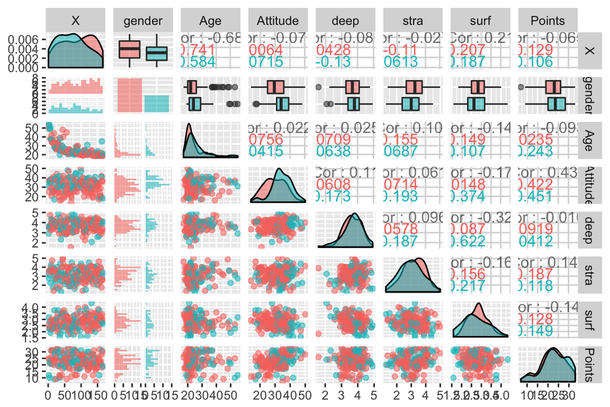

From all the variables analysed, strategic_questions is the one that shows a more normal distributon, all the other data seems slighly to dramatically skewed.

- Based in the previous observations it seems interesting to visualize how the attitute (that seems to vary most with gender) correlates with the acquired Points.

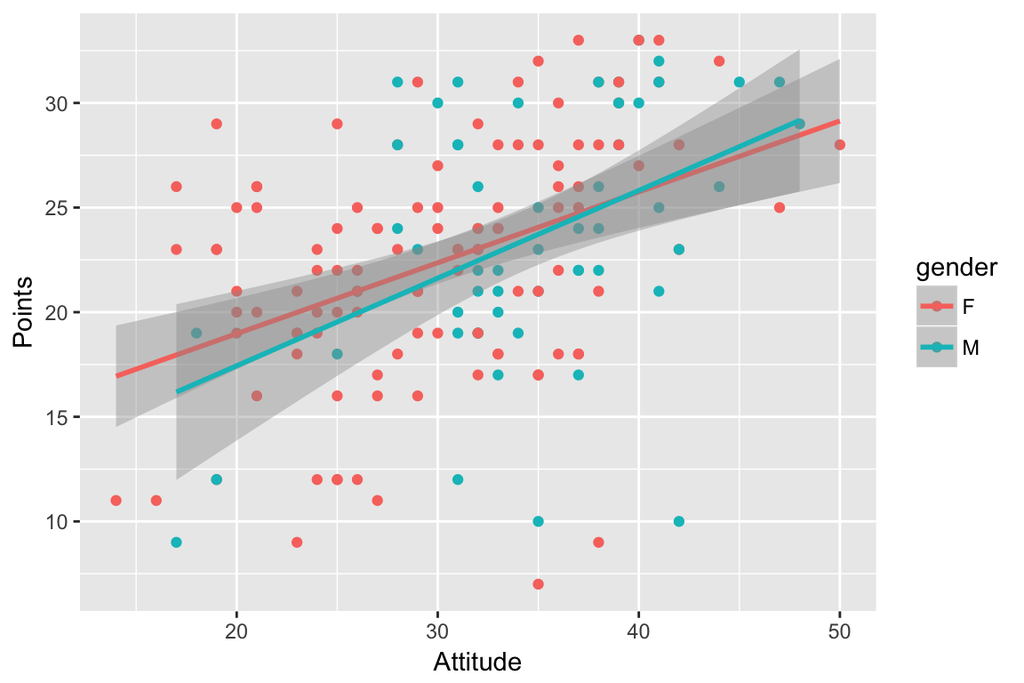

You can verify in the graph how the correlation trend varies between female (red line) and male (blue line). The grey area in the graph shows you how this data varies.

```r
#Linear model with three explanatory variables
my_model <- lm(formula = Points ~ Attitude + stra + surf, data = learning2014)

#Summary of the linear model
summary(my_model)
```

```
##
## Call:
## lm(formula = Points ~ Attitude + stra + surf, data = learning2014)
##
## Residuals:
##      Min       1Q   Median       3Q      Max
## -17.1550  -3.4346   0.5156   3.6401  10.8952
##
## Coefficients:
##             Estimate Std. Error t value Pr(>|t|)
## (Intercept) 11.01711    3.68375   2.991  0.00322 **
## Attitude     0.33952    0.05741   5.913 1.93e-08 ***
## stra         0.85313    0.54159   1.575  0.11716
## surf        -0.58607    0.80138  -0.731  0.46563
## ---
## Signif. codes:  0 '***' 0.001 '**' 0.01 '*' 0.05 '.' 0.1 ' ' 1
##
## Residual standard error: 5.296 on 162 degrees of freedom
## Multiple R-squared:  0.2074, Adjusted R-squared:  0.1927
## F-statistic: 14.13 on 3 and 162 DF,  p-value: 3.156e-08
```

Analyses of the linear regression tell you that by each attitude point up the students have a chance of getting mote 0.34 points. This is the more significant relationship with the points obtained (p = 0.001)

```r
#Linear model with three explanatory variables
my_model <- lm(formula = Points ~ Attitude, data = learning2014)

#Summary of the linear model
summary(my_model)
```

```
##
## Call:
## lm(formula = Points ~ Attitude, data = learning2014)
##
## Residuals:
##      Min       1Q   Median       3Q      Max
## -16.9763  -3.2119   0.4339   4.1534  10.6645
##
## Coefficients:
##             Estimate Std. Error t value Pr(>|t|)
## (Intercept) 11.63715    1.83035   6.358 1.95e-09 ***
## Attitude     0.35255    0.05674   6.214 4.12e-09 ***
## ---
## Signif. codes:  0 '***' 0.001 '**' 0.01 '*' 0.05 '.' 0.1 ' ' 1
##
## Residual standard error: 5.32 on 164 degrees of freedom
## Multiple R-squared:  0.1906, Adjusted R-squared:  0.1856
## F-statistic: 38.61 on 1 and 164 DF,  p-value: 4.119e-09
```

**Graphical model validation**

**Normal Q-Q plot**

```r
library(ggfortify)
```

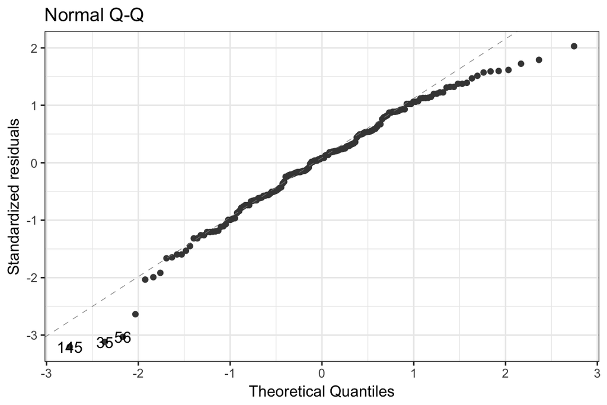

```r
autoplot(my_model, which= 2) +
     theme_bw()
```

# 3 Logistic regression

*This chapter introduces you the concept of logistic regression. Which in a very simplified matter meand how well your data fits to the idea of a linear correlation between the variables, arguments you are testing.*

# 4 *About this week working data set “Student Performance Data Set*

> “This data approach student achievement in secondary education of two Portuguese schools. The data attributes include student grades, demographic, social and school related features) and it was collected by using school reports and questionnaires. Two datasets are provided regarding the performance in two distinct subjects: Mathematics (mat) and Portuguese language (por). In [Cortez and Silva, 2008], the two datasets were modeled under binary/five-level classification and regression tasks (see [paper](http://www3.dsi.uminho.pt/pcortez/student.pdf) source for more details).”

## 4.1 1. **Load the combined data set from wrangling exercise from your local folder:**

```
##       X school sex age address famsize Pstatus Medu Fedu     Mjob     Fjob
## 1     1     GP   F  18       U     GT3       A    4    4  at_home  teacher
## 2     2     GP   F  17       U     GT3       T    1    1  at_home    other
## 3     3     GP   F  15       U     LE3       T    1    1  at_home    other
## 4     4     GP   F  15       U     GT3       T    4    2   health services
## 5     5     GP   F  16       U     GT3       T    3    3    other    other
## 6     6     GP   M  16       U     LE3       T    4    3 services    other
## 7     7     GP   M  16       U     LE3       T    2    2    other    other
## 8     8     GP   F  17       U     GT3       A    4    4    other  teacher
## 9     9     GP   M  15       U     LE3       A    3    2 services    other
## 10   10     GP   M  15       U     GT3       T    3    4    other    other
## 11   11     GP   F  15       U     GT3       T    4    4  teacher   health
## 12   12     GP   F  15       U     GT3       T    2    1 services    other
## 13   13     GP   M  15       U     LE3       T    4    4   health services
## 14   14     GP   M  15       U     GT3       T    4    3  teacher    other
```

[output cut: 1517 more lines]

The data wrangling exercise combined the two student alcohol consumption data sets. Variables not used for joining the two data have been combined by averaging (including the grade variables) - ‘alc_use’ is the average of ‘Dalc’ and ‘Walc’ - ‘high_use’ is TRUE if ‘alc_use’ is higher than 2 and FALSE otherwise

## 4.2 2. **Analysis of the data**

### 4.2.1 2.1 *start by viewing the variable names, example of the first rows in the data, summary of the overall data*

```
##  [1] "X"          "school"     "sex"        "age"        "address"
##  [6] "famsize"    "Pstatus"    "Medu"       "Fedu"       "Mjob"
## [11] "Fjob"       "reason"     "nursery"    "internet"   "guardian"
## [16] "traveltime" "studytime"  "failures"   "schoolsup"  "famsup"
## [21] "paid"       "activities" "higher"     "romantic"   "famrel"
## [26] "freetime"   "goout"      "Dalc"       "Walc"       "health"
## [31] "absences"   "G1"         "G2"         "G3"         "alc_use"
## [36] "high_use"
```

```
##   X school sex age address famsize Pstatus Medu Fedu     Mjob     Fjob
## 1 1     GP   F  18       U     GT3       A    4    4  at_home  teacher
## 2 2     GP   F  17       U     GT3       T    1    1  at_home    other
## 3 3     GP   F  15       U     LE3       T    1    1  at_home    other
## 4 4     GP   F  15       U     GT3       T    4    2   health services
## 5 5     GP   F  16       U     GT3       T    3    3    other    other
## 6 6     GP   M  16       U     LE3       T    4    3 services    other
##       reason nursery internet guardian traveltime studytime failures
## 1     course     yes       no   mother          2         2        0
## 2     course      no      yes   father          1         2        0
## 3      other     yes      yes   mother          1         2        2
## 4       home     yes      yes   mother          1         3        0
## 5       home     yes       no   father          1         2        0
## 6 reputation     yes      yes   mother          1         2        0
##   schoolsup famsup paid activities higher romantic famrel freetime goout
## 1       yes     no   no         no    yes       no      4        3     4
## 2        no    yes   no         no    yes       no      5        3     3
## 3       yes     no  yes         no    yes       no      4        3     2
## 4        no    yes  yes        yes    yes      yes      3        2     2
## 5        no    yes  yes         no    yes       no      4        3     2
## 6        no    yes  yes        yes    yes       no      5        4     2
##   Dalc Walc health absences G1 G2 G3 alc_use high_use
## 1    1    1      3        5  2  8  8     1.0    FALSE
## 2    1    1      3        3  7  8  8     1.0    FALSE
## 3    2    3      3        8 10 10 11     2.5     TRUE
## 4    1    1      5        1 14 14 14     1.0    FALSE
## 5    1    2      5        2  8 12 12     1.5    FALSE
## 6    1    2      5        8 14 14 14     1.5    FALSE
```

```
##        X          school   sex          age        address famsize
##  Min.   :  1.00   GP:342   F:198   Min.   :15.00   R: 81   GT3:278
##  1st Qu.: 96.25   MS: 40   M:184   1st Qu.:16.00   U:301   LE3:104
##  Median :191.50                    Median :17.00
##  Mean   :191.50                    Mean   :16.59
##  3rd Qu.:286.75                    3rd Qu.:17.00
##  Max.   :382.00                    Max.   :22.00
##  Pstatus      Medu            Fedu             Mjob           Fjob
##  A: 38   Min.   :0.000   Min.   :0.000   at_home : 53   at_home : 16
##  T:344   1st Qu.:2.000   1st Qu.:2.000   health  : 33   health  : 17
##          Median :3.000   Median :3.000   other   :138   other   :211
##          Mean   :2.806   Mean   :2.565   services: 96   services:107
##          3rd Qu.:4.000   3rd Qu.:4.000   teacher : 62   teacher : 31
##          Max.   :4.000   Max.   :4.000
##         reason    nursery   internet    guardian     traveltime
##  course    :140   no : 72   no : 58   father: 91   Min.   :1.000
##  home      :110   yes:310   yes:324   mother:275   1st Qu.:1.000
##  other     : 34                       other : 16   Median :1.000
##  reputation: 98                                    Mean   :1.448
##                                                    3rd Qu.:2.000
##                                                    Max.   :4.000
##    studytime        failures      schoolsup famsup     paid     activities
##  Min.   :1.000   Min.   :0.0000   no :331   no :144   no :205   no :181
##  1st Qu.:1.000   1st Qu.:0.0000   yes: 51   yes:238   yes:177   yes:201
##  Median :2.000   Median :0.0000
##  Mean   :2.037   Mean   :0.2016
##  3rd Qu.:2.000   3rd Qu.:0.0000
##  Max.   :4.000   Max.   :3.0000
##  higher    romantic      famrel         freetime        goout
##  no : 18   no :261   Min.   :1.000   Min.   :1.00   Min.   :1.000
##  yes:364   yes:121   1st Qu.:4.000   1st Qu.:3.00   1st Qu.:2.000
##                      Median :4.000   Median :3.00   Median :3.000
##                      Mean   :3.937   Mean   :3.22   Mean   :3.113
##                      3rd Qu.:5.000   3rd Qu.:4.00   3rd Qu.:4.000
##                      Max.   :5.000   Max.   :5.00   Max.   :5.000
##       Dalc            Walc           health         absences
##  Min.   :1.000   Min.   :1.000   Min.   :1.000   Min.   : 0.0
##  1st Qu.:1.000   1st Qu.:1.000   1st Qu.:3.000   1st Qu.: 1.0
##  Median :1.000   Median :2.000   Median :4.000   Median : 3.0
##  Mean   :1.482   Mean   :2.296   Mean   :3.573   Mean   : 4.5
##  3rd Qu.:2.000   3rd Qu.:3.000   3rd Qu.:5.000   3rd Qu.: 6.0
##  Max.   :5.000   Max.   :5.000   Max.   :5.000   Max.   :45.0
##        G1              G2              G3           alc_use
##  Min.   : 2.00   Min.   : 4.00   Min.   : 0.00   Min.   :1.000
##  1st Qu.:10.00   1st Qu.:10.00   1st Qu.:10.00   1st Qu.:1.000
##  Median :12.00   Median :12.00   Median :12.00   Median :1.500
##  Mean   :11.49   Mean   :11.47   Mean   :11.46   Mean   :1.889
##  3rd Qu.:14.00   3rd Qu.:14.00   3rd Qu.:14.00   3rd Qu.:2.500
##  Max.   :18.00   Max.   :18.00   Max.   :18.00   Max.   :5.000
##   high_use
##  Mode :logical
##  FALSE:268
##  TRUE :114
##
##
##
```

- With this overview of the data you can basically just check one by one what are the minimum and maximum values for each variable and also the total number of female and male students in the course.

### 4.2.2 2.2 *Another why to inspect the data is to check summaries of the data by groups of variables*

```
## # A tibble: 4 x 4
## # Groups:   sex [?]
##      sex high_use count mean_grade
##   <fctr>    <lgl> <int>      <dbl>
## 1      F    FALSE   156   11.39744
## 2      F     TRUE    42   11.71429
## 3      M    FALSE   112   12.20536
## 4      M     TRUE    72   10.27778
```

### 4.2.3 2.1 *Analyse the relationship between the levels of high alcohol consuption and failure, absences, sex and grades of the students.*

One could associate that an increased alcohol consuption will lead to an increase in failures, absences from school and also with a decrease in the final grades (grade form the 3rd period = G3). The differences of alcohol intake amongs sex and age seems also interesting to explore (once there is the stereotyped idea that males drink more and younger students are not leagally allowed to drink).

```
##
## Call:
## glm(formula = high_use ~ age + absences + sex + G3, family = "binomial",
##     data = alc)
##
## Deviance Residuals:
##     Min       1Q   Median       3Q      Max
## -2.2729  -0.8326  -0.6292   1.0442   2.1190
##
## Coefficients:
##             Estimate Std. Error z value Pr(>|z|)
## (Intercept) -3.38339    1.84796  -1.831 0.067120 .
## age          0.13985    0.10328   1.354 0.175690
## absences     0.08964    0.02309   3.882 0.000104 ***
## sexM         0.98580    0.24184   4.076 4.58e-05 ***
## G3          -0.06631    0.03624  -1.830 0.067277 .
## ---
## Signif. codes:  0 '***' 0.001 '**' 0.01 '*' 0.05 '.' 0.1 ' ' 1
##
## (Dispersion parameter for binomial family taken to be 1)
##
##     Null deviance: 465.68  on 381  degrees of freedom
## Residual deviance: 423.66  on 377  degrees of freedom
## AIC: 433.66
##
## Number of Fisher Scoring iterations: 4
```

```
## (Intercept)         age    absences        sexM          G3
## -3.38338833  0.13985344  0.08963638  0.98580237 -0.06630516
```

## 4.3 3. **Inspect numerically and graphically the distributions of the previously chosen variables and their relationship with alcohol consumption**

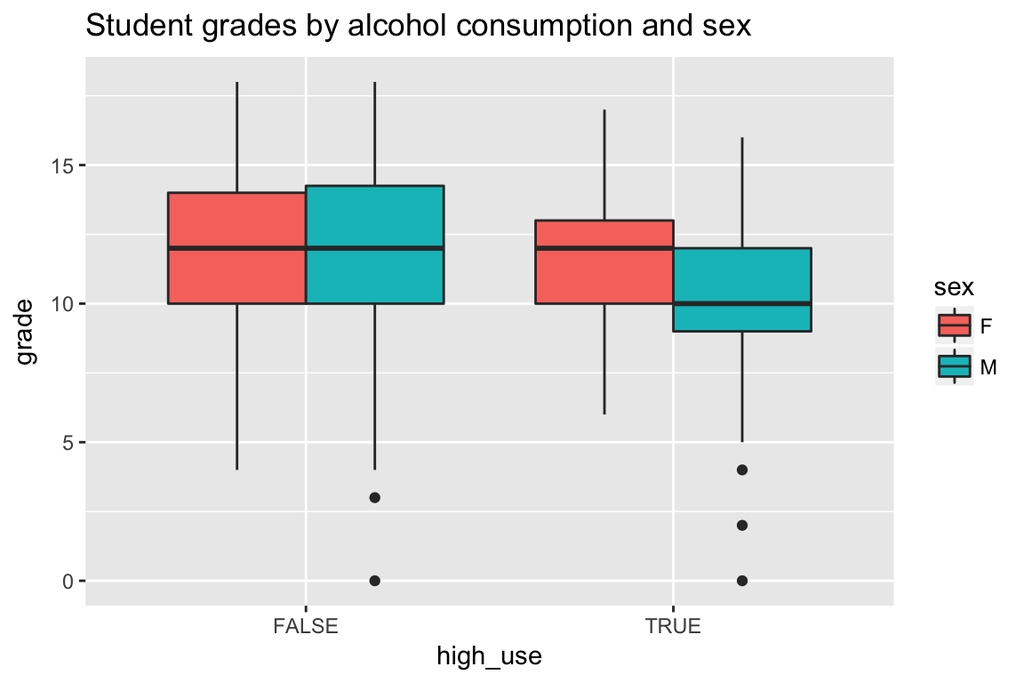

[output not shown]

You can observe that high use of alcohol didn’t alter the average final grades (G3 in the data set) of the female students, and only sligly decreases the amount of the maximum grades. As for the male students you can see a clear drop in the average grades as also the maximum grades (you can see this from the variation lines)

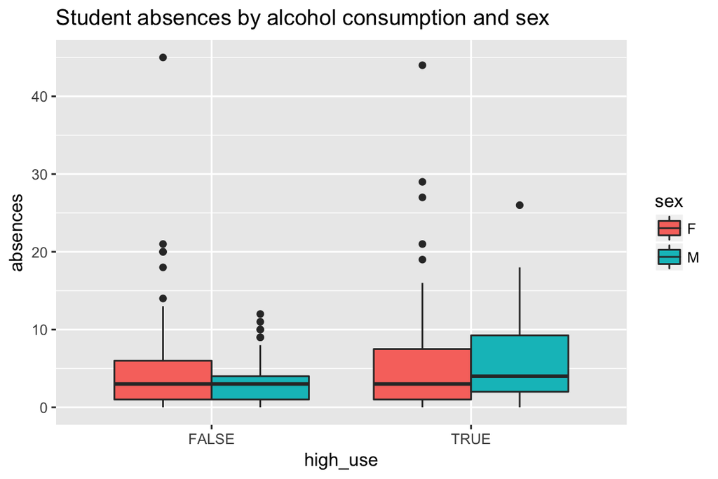

[output not shown]

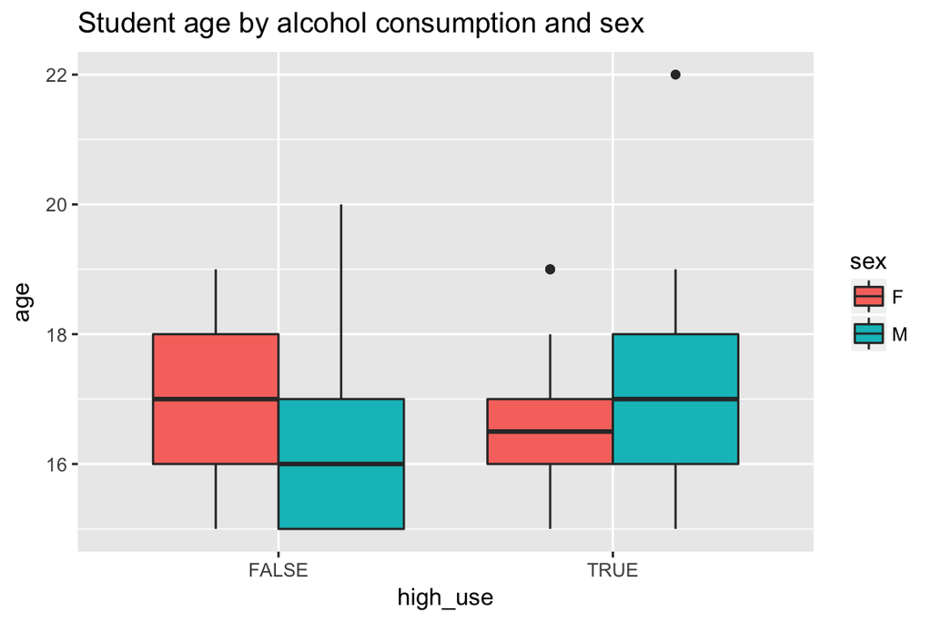

```
##
##
##    Cell Contents
## |-------------------------|
## |                       N |
## | Chi-square contribution |
## |           N / Row Total |
## |           N / Col Total |
## |         N / Table Total |
## |-------------------------|
##
##
## Total Observations in Table:  382
##
##
##              | alc$age
## alc$high_use |        15 |        16 |        17 |        18 |        19 |        20 |        22 | Row Total |
## -------------|-----------|-----------|-----------|-----------|-----------|-----------|-----------|-----------|
##        FALSE |        63 |        79 |        64 |        54 |         7 |         1 |         0 |       268 |
##              |     0.671 |     0.206 |     0.540 |     0.141 |     0.067 |     0.127 |     0.702 |           |
##              |     0.235 |     0.295 |     0.239 |     0.201 |     0.026 |     0.004 |     0.000 |     0.702 |
##              |     0.778 |     0.738 |     0.640 |     0.667 |     0.636 |     1.000 |     0.000 |           |
##              |     0.165 |     0.207 |     0.168 |     0.141 |     0.018 |     0.003 |     0.000 |           |
## -------------|-----------|-----------|-----------|-----------|-----------|-----------|-----------|-----------|
##         TRUE |        18 |        28 |        36 |        27 |         4 |         0 |         1 |       114 |
##              |     1.576 |     0.484 |     1.270 |     0.331 |     0.157 |     0.298 |     1.649 |           |
##              |     0.158 |     0.246 |     0.316 |     0.237 |     0.035 |     0.000 |     0.009 |     0.298 |
##              |     0.222 |     0.262 |     0.360 |     0.333 |     0.364 |     0.000 |     1.000 |           |
##              |     0.047 |     0.073 |     0.094 |     0.071 |     0.010 |     0.000 |     0.003 |           |
## -------------|-----------|-----------|-----------|-----------|-----------|-----------|-----------|-----------|
## Column Total |        81 |       107 |       100 |        81 |        11 |         1 |         1 |       382 |
##              |     0.212 |     0.280 |     0.262 |     0.212 |     0.029 |     0.003 |     0.003 |           |
## -------------|-----------|-----------|-----------|-----------|-----------|-----------|-----------|-----------|
##
##
```

## 4.4 4. *Use logistic regression to statistically explore the relationship between chosen variables and the binary high/low alcohol consumption variable as the target variable.*

```
##
## Call:
## glm(formula = high_use ~ age + absences + sex + G3, family = "binomial",
##     data = alc)
##
## Deviance Residuals:
##     Min       1Q   Median       3Q      Max
## -2.2729  -0.8326  -0.6292   1.0442   2.1190
##
## Coefficients:
##             Estimate Std. Error z value Pr(>|z|)
## (Intercept) -3.38339    1.84796  -1.831 0.067120 .
## age          0.13985    0.10328   1.354 0.175690
## absences     0.08964    0.02309   3.882 0.000104 ***
## sexM         0.98580    0.24184   4.076 4.58e-05 ***
## G3          -0.06631    0.03624  -1.830 0.067277 .
## ---
## Signif. codes:  0 '***' 0.001 '**' 0.01 '*' 0.05 '.' 0.1 ' ' 1
##
## (Dispersion parameter for binomial family taken to be 1)
##
##     Null deviance: 465.68  on 381  degrees of freedom
## Residual deviance: 423.66  on 377  degrees of freedom
## AIC: 433.66
##
## Number of Fisher Scoring iterations: 4
```

```
## (Intercept)         age    absences        sexM          G3
## -3.38338833  0.13985344  0.08963638  0.98580237 -0.06630516
```

### 4.4.1 4.1 *Present and interpret the coefficients of the model as odds ratios and provide confidence intervals for them.*

```
##                     OR        2.5 %   97.5 %
## (Intercept) 0.03393229 0.0008683319 1.237502
## age         1.15010522 0.9401979286 1.410759
## absences    1.09377649 1.0474354900 1.146836
## sexM        2.67996134 1.6781593816 4.338864
## G3          0.93584524 0.8710385897 1.004426
```

## 4.5 5. *Compute the total proportion of inaccurately classified individuals (= the training error) and comment on all the results.*

```
##    age absences sex high_use probability prediction
## 1   18        5   F    FALSE   0.2792297      FALSE
## 2   17        3   F    FALSE   0.2197006      FALSE
## 3   15        8   F     TRUE   0.2145267      FALSE
## 4   15        1   F    FALSE   0.1067647      FALSE
## 5   16        2   F    FALSE   0.1465247      FALSE
## 6   16        8   M    FALSE   0.4082723      FALSE
## 7   16        0   M    FALSE   0.2777614      FALSE
## 8   17        4   F    FALSE   0.2124223      FALSE
## 9   15        0   M    FALSE   0.1834303      FALSE
## 10  15        0   M    FALSE   0.2265217      FALSE
```

```
##         prediction
## high_use FALSE TRUE
##    FALSE   255   13
##    TRUE     84   30
```

You can check in the tables in how many student cases the prediction wouldn’t have assumed a correlation for high use of alcohol and the selected variables. In the 2 x 2 summary table you can see that in 84 cases the prediction claimed no relation but in the real cases you could detect a relationship between the variables. 30 cases there was in both prediction and data analysis a relation between high use of alcohol and the chosen variables.

## 4.6 6. *Perform 10-fold cross-validation on your model*

```
## [1] 0.2539267
```

```
## [1] 0.2670157
```

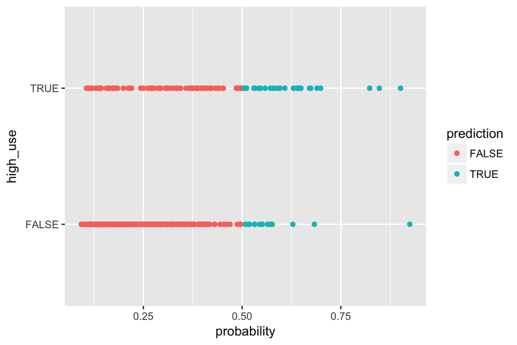

```
##         prediction
## high_use      FALSE       TRUE        Sum
##    FALSE 0.66753927 0.03403141 0.70157068
##    TRUE  0.21989529 0.07853403 0.29842932
##    Sum   0.88743455 0.11256545 1.00000000
```

In this graph you can more easily evaluate how the predictions correlate with the real probability of the high use of alcohol being significantly related with the chosen variables.